# Regression under differential privacy

LJ

2019-12-21

```r
library(readxl)
library(data.table)
library(xlsx)
library(pROC)
library(ROCR)
library(tidyverse)
library(caret)
library(ggpubr)
library(rms)
library(dplyr)
library(ggplot2)
library(DT)
library(tableone)
library(glmnet)
library(ncvreg)
library(MASS)
library(reshape2)
library(Hmisc)
library(sjPlot) # beautiful summaries
library(sjmisc)
library(sjlabelled)


ljtheme <- theme_bw() + theme(panel.border = element_rect(color = "black", size = 2),
                                 # Remove panel grid lines
                                panel.grid.major = element_blank(),
                                panel.grid.minor = element_blank())
```

#### Regression Analysis on differentially private synthetic datasets

Data release without disclosure of personal information is increasingly challenging with recent technological advancements. Our presence in multiple databases (e.g. social media sites) increases the prospect of participant re-identification in de-identified dataset through linkage attacks. Differ- ential privacy (DP) provides a formal guarantee that an individual participant’s data would remain private. However, the utility of synthetic datasets generated through DP mechanisms are sometimes undesirable. Pooled (or aggregate) synthetic data has proven a reliable substitute for individual data without the formal privacy guarantees provided by DP mechanisms. To bridge this gap, we propose a hybrid mechanism, a pooled differentially private algorithm (PoolDiv), that utilizes a relax (, δ) privacy budget and the data aggregation techniques of pooling to generate synthetic data. We conduct extensive simulations to compare the performance of least square estimation on synthetic data generated from (1) traditional DP mechanisms (i.e. randomized response mechanism and histogram perturbation algorithm), (2) pooling data synthesis mechanism, and (3) PoolDiv. We assess the performance of the mechanism on simulated datasets and on real data.

### simulate data here

```r
# simulate the data
sim_lsdata<-function(n=1000, p=4, sigma.star=1/2){
  beta.star=rnorm(p)
  X=cbind(1, matrix(rnorm(n*(p-1)), nrow=n, ncol=(p-1)))
  y=X%*%beta.star + sigma.star*rnorm(n)
  data=data.frame(cbind(y,X));
  colnames(data)<-c("y",paste0("X",0:(p-1),sep = ""))
  dat<-data[,-2]
  return(data.frame(dat) )
}

simdat = sim_lsdata(n=1000, p=4, sigma.star=1/2)


xbar=apply(simdat, 2, mean);
simdat=scale(simdat, center=xbar, scale=FALSE)
```

#### Laplace mechanism

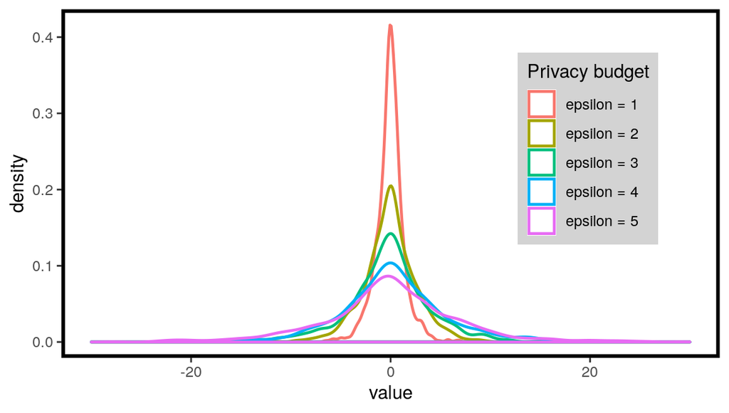

```r
library(rmutil)
lap_values = rlaplace(n = 1000,m = 0,s = 0.1)

N = 1000
r5 <- rlaplace(n = N,m = 0,s = 5)
r4 <- rlaplace(n = N,m = 0,s = 4)
r3 =  rlaplace(n = N,m = 0,s = 3)
r2 <- rlaplace(n = N,m = 0,s = 2)
r1 <- rlaplace(n = N,m = 0,s = 1)

data_list<-list(eps5 = r5,eps4 = r4,eps3 = r3,eps2 = r2, eps1 = r1)

data<- melt(data_list)

ggplot(data,aes(x=value, col=L1)) + geom_density(alpha=0.25,size=0.8) + ljtheme  +
  scale_color_discrete(name = "Privacy budget",
                 limits = c("eps1","eps2","eps3","eps4","eps5"),
                 labels = c(paste(expression(epsilon),"=",1),
                            paste(expression(epsilon),"=",2),
                            paste(expression(epsilon),"=",3),
                            paste(expression(epsilon),"=",4),
                            paste(expression(epsilon),"=",5))) + xlim(c(-30,30)) +
  theme(legend.position = c(0.8, 0.6),
        legend.background = element_rect(fill="lightgray",
                                  size=0.5, linetype="solid"))
```

remark: laplace noise addition for continuous variable

#### random mechanisns

randomized response mechanism

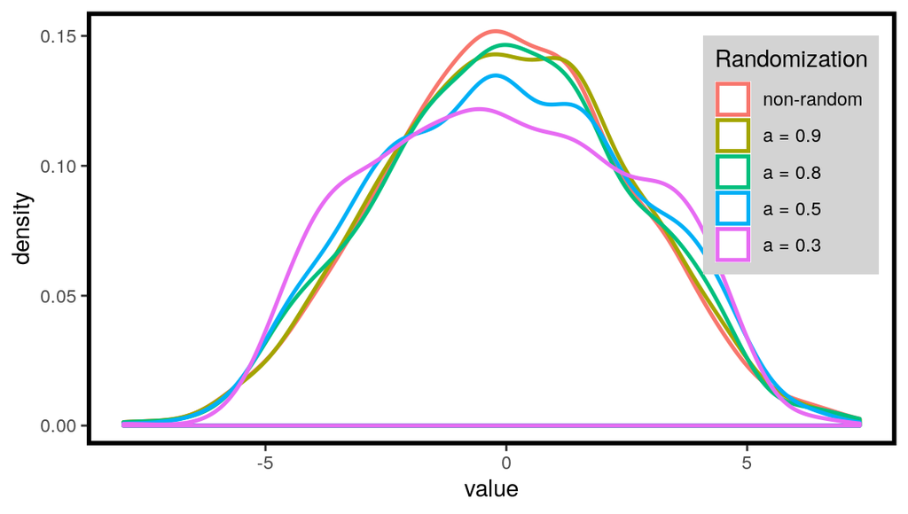

```r
alpha = beta = 0.5
# the randomized mechanism
random_mechanism = function(d, alpha=0.5, beta=0.5){
  foo = function(d){
  if(runif(1,0,1)<alpha){
    return(d)
    }
  else if(runif(1,0,1)<beta){
      return(runif(n = 1,min = -5,max = 5))
      }
  else{ return(d)}
  }
  return(apply(as.matrix(d), 1, foo))
}

N = 10^4
#data = rnorm(N,mean = 0,n = 25)
data = simdat[,1]

r2 <- random_mechanism(data,alpha = 0.9,beta = 0.75)
r3 <- random_mechanism(data,alpha = 0.8,beta = 0.75)
r4 =  random_mechanism(data,alpha = 0.5,beta = 0.75)
r5 <- random_mechanism(data,alpha = 0.3,beta = 0.75)
r1 <- data

data_list<-list(r5 = r5,r4 = r4,r3 = r3,r2 = r2, r1 = r1)

data<- melt(data_list)

ggplot(data,aes(x=value, col=L1)) + geom_density(alpha=0.25,size=0.9) + ljtheme  +
  scale_color_discrete(name = "Randomization",
                 limits = c("r1","r2","r3","r4","r5"),
                 labels = c("non-random",
                            paste(expression(a),"=",0.9),
                            paste(expression(a),"=",0.8),
                            paste(expression(a),"=",0.5),
                            paste(expression(a),"=",0.3)))+
  theme(legend.position = c(0.87, 0.67),
        legend.background = element_rect(fill="lightgray", linetype="solid"))
```

remark: random mechanism sampling

#### exponential mechanism

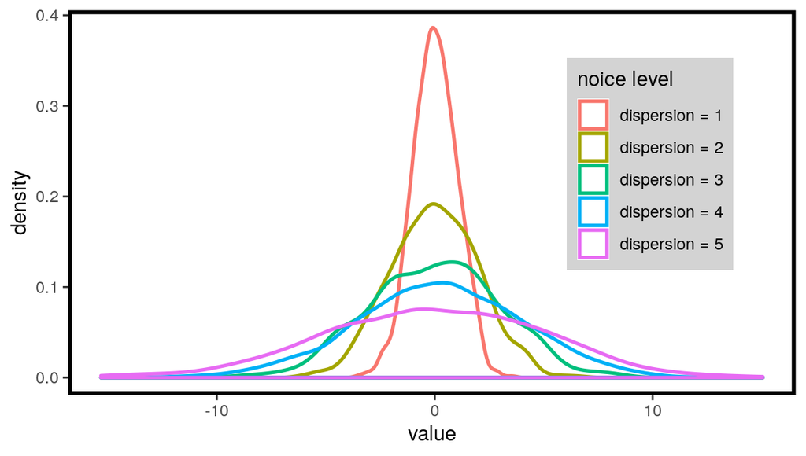

```r
library(rmutil)
gaus_values = rnorm(n = 1000,mean = 0,sd = 0.5)

N = 1000
r1 <- rnorm(n = 1000,mean = 0,sd = 1)
r2 <- rnorm(n = 1000,mean = 0,sd = 2)
r3 =  rnorm(n = 1000,mean = 0,sd = 3)
r4 <- rnorm(n = 1000,mean = 0,sd = 4)
r5 <- rnorm(n = 1000,mean = 0,sd = 5)

data_list<-list(eps5 = r5,eps4 = r4,eps3 = r3,eps2 = r2, eps1 = r1)

data<- melt(data_list)
ggplot(data,aes(x=value, col=L1)) + geom_density(alpha=0.25,size=0.9) + ljtheme  +
    scale_color_discrete(name = "noice level",
                 limits = c("eps1","eps2","eps3","eps4","eps5"),
                 labels = c(paste(expression(dispersion),"=",1),
                            paste(expression(dispersion),"=",2),
                            paste(expression(dispersion),"=",3),
                            paste(expression(dispersion),"=",4),
                            paste(expression(dispersion),"=",5))) +
  theme(legend.position = c(0.8, 0.6),
        legend.background = element_rect(fill="lightgray",
                                  size=0.5, linetype="solid"))
```

### Generating synthetic data

#### Algorithm 1:

- randomized function k for a binary dataset

We use here a randomized algorithm to generate M multiple datasets each of budget $\epsilon /M$.

```r
# Toy binary data
ybinary<-ifelse(simdat[,1]>0.5,0,1)
# assume a binomial likelihood for the data
# sufficient stats
 ybar = mean(ybinary)

 # sample from binomial
 data = ybinary
 syn_private_binom<-function(data,alp1=0.9,alp2=1.75,n_out=500, epsil = 8){
   if (min(alp1,alp2)<n_out/(exp(epsil)-1)) {
     print("differential privacy condition not satisfied")
   }
   n = length(data)
   x = sum(data)
   Q =  seq(0, 1, length = n_out)
   pbar = pbeta(q = Q,shape1 = alp1+x, shape2 = alp2+n-x)
   result = rbinom(n = length(pbar),size = 1,prob = pbar)
   return(ifelse(result>0,0,1))
 }

synval = syn_private_binom(data)
#chisq.test(data,syntheticval)
dat = data.frame(val=as.factor(c(synval,data)),
                 category = c(rep("New",length(synval)),
                              rep("Private",length(data))))

#str(dat)
vars = c("val")
Table1<-CreateTableOne(vars = vars, strata = "category",
                       data = dat, test = TRUE)
print(Table1, smd=F,showAllLevels = TRUE,noSpaces = TRUE)
```

```
##          Stratified by category
##           level New        Private    p     test
##   n             500        1000
##   val (%) 0     211 (42.2) 421 (42.1) 1.000
##           1     289 (57.8) 579 (57.9)
```

```r
levels(dat$category)<-c("Synthetic data","Private data")

cat("Toy example for beta-binomial mechanism")
```

```
## Toy example for beta-binomial mechanism
```

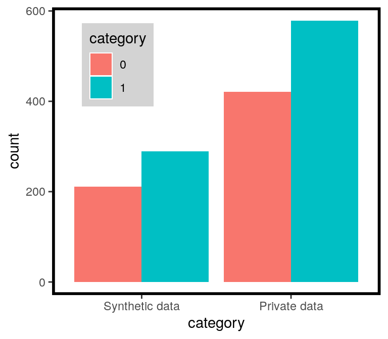

```r
ggplot(dat, aes(category, ..count..)) + geom_bar(aes(fill = val), position = "dodge") + ljtheme +
    scale_fill_discrete(name = "category") +
  theme(legend.position = c(0.2, 0.8),
        legend.background = element_rect(fill="lightgray",
                                  size=0.5, linetype="solid"))
```

Remark: synthetic binary distribution generation

#### Algorithm II

Histogram Perturbation for contingency tables. The algorithm is based on the contingency table representation of data

```r
# Toy contingency table data
JobSat <- matrix(c(1,2,1,0, 3,3,6,1, 10,10,14,9, 6,7,12,11), 4, 4)
dimnames(JobSat) = list(income=c("< 15k", "15-25k", "25-40k", "> 40k"),
                        satisfaction=c("VeryD", "LittleD", "ModerateS", "VeryS"))
#as.data.frame(JobSat)
JobSat <- as.table(JobSat)
#str(JobSat)
cat("private contingency table dataset")
```

```
## private contingency table dataset
```

```r
JobSat
```

```
##         satisfaction
## income   VeryD LittleD ModerateS VeryS
##   < 15k      1       3        10     6
##   15-25k     2       3        10     7
##   25-40k     1       6        14    12
##   > 40k      0       1         9    11
```

```r
# For spliting continuous variables into quantiles
qvals = function(X,P=seq(0,1,length.out = 20)){
  val = table(cut(X, breaks = quantile(X,probs = P)))
  return( as.matrix(val)[,1] )
}
#apply(simdat, 2, qvals)
#dat = as.data.frame(apply(simdat, 2, qvals))

# To measure the sensitivity of database
Senseval = function(dat){ # privacy sensitivity
  return(abs(max(dat)-min(dat)))
}



dat<-as.matrix(as.vector(JobSat))
perturb_hist<-function(dat,epsil = 0.005){ # def histogram perturbation function
  sense = Senseval(dat)
  noise = replicate(n = length(dat),
                  expr = rlaplace(m = 0,s = epsil/sense))
  di = dat/sum(dat) + noise
  di_bar = ifelse(di<0,0,di)
  pi_bar = di_bar/sum(di_bar)
  return(pi_bar )
}

temp = matrix(as.vector(apply(dat, 2, perturb_hist)),nrow = 1)

#sample from multinomial
Xreturn = rMultinom(probs = temp,m = 16)

syntheticdat = as.table(matrix(Xreturn,nrow = 4))
rownames(syntheticdat)<-rownames(JobSat)
colnames(syntheticdat)<-colnames(JobSat)

syntheticdat = as.data.frame(syntheticdat)
returnprivate<-as.data.frame(JobSat)

colnames(syntheticdat)<-colnames(returnprivate)
all_dat<-rbind(returnprivate,syntheticdat)
all_dat$datatype<-c(rep("private",length(returnprivate$Freq)),
                    rep("synthetic",length(syntheticdat$Freq)))

all_data_flat = all_dat %>%
  slice(rep(1:n(), Freq))

df = all_dat
cat("Toy example with count data")
```

```
## Toy example with count data
```

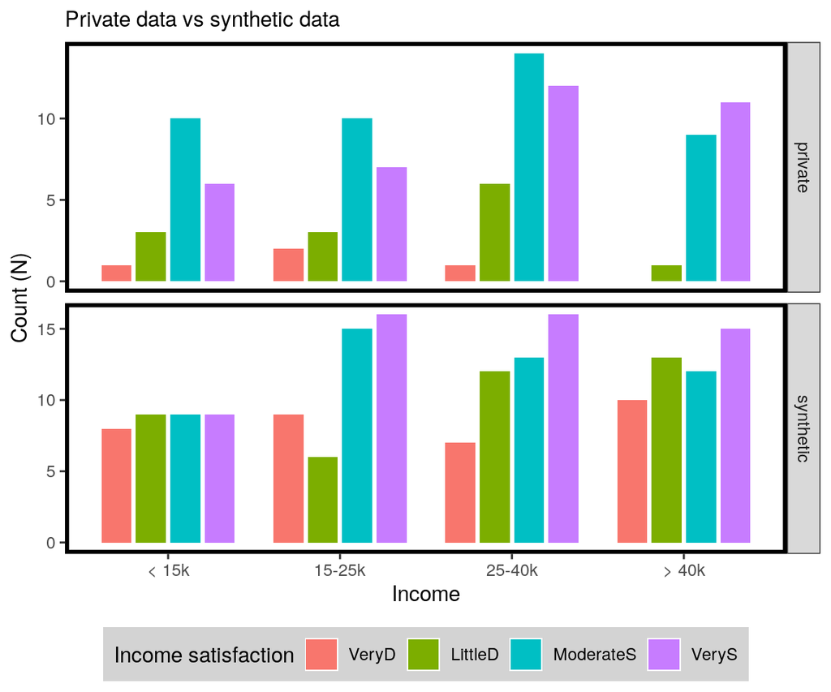

```r
ggplot(df, aes(income, Freq)) +
  geom_bar(stat = "identity", position = position_dodge(0.8),width = 0.7,aes(fill = satisfaction))+
  ylab("Count (N)") + xlab("Income") + #coord_flip() +
  facet_grid(datatype ~., scales = "free")  + theme(axis.text.x = element_text(vjust = +.65,angle = 45, size = 0.15)) +
  labs(subtitle="Private data vs synthetic data")+
  scale_fill_hue(name = "Income satisfaction") + ljtheme +
    theme(legend.position = "bottom",
        legend.background = element_rect(fill="lightgray",
                                  size=0.5, linetype="solid"))
```

#### Algorithm III

We use here the Multinomial-Dirichlet Synthesizer. The algorithm is specified in the manuscript.

Remark: Not included in this assessment

### Pooled synthetic data

```r
# Function to create synthetic pool data
pool<-function(poolsize=2,data){
  G = poolsize;
  n = dim(data)[1]
  pools<-n/G
  pooldata<-data.frame(matrix(0,nrow = pools,ncol = NCOL(data)))
  colnames(pooldata)<-colnames(data)
  if (poolsize==2) {
    pooldata<-data[seq(1,n-1,G),]+data[seq(2,n,G),]
  }
  if (poolsize==4) {

    pooldata<-parse(text = paste(paste(paste("data[seq(",1:G,",n -G +",1:G,",G),] + "),
                               collapse = ""),"0") )
    pooldata = eval(pooldata)
    }

  if (poolsize==6) {

    pooldata<-parse(text = paste(paste(paste("data[seq(",1:G,",n -G +",1:G,",G),] + "),
                               collapse = ""),"0") )
    pooldata = eval(pooldata)
  }

  if (poolsize==10) {
    pooldata<-parse(text = paste(paste(paste("data[seq(",1:G,",n -G +",1:G,",G),] + "),
                               collapse = ""),"0") )
    pooldata = eval(pooldata)
  }

  return(pooldata)
}


poolsize=2
pool2  = pool(poolsize=2,simdat)
```

### All the datasets for comparison

- simulated data
- differential private synthetic data using randomized algorithm
- differential private synthetic data using histogram perturbation algorithm
- pooled synthetic data
- pooled differentially private synthetic data

```r
simdat<-as.data.frame(simdat)
train.control <- trainControl(method = "cv", number = 10, repeats = 5)

simulated<-simdat
diff_index<-random_mechanism(simdat[,1],alpha = 0.75,beta = 0.6)
diff_randomized<-simdat
diff_randomized$y<-diff_index; randomized_keep<-diff_randomized
## histogram perturbation, used all_dat
# laplace noise
diff_laplace <-simdat
laplace_mech<-function(data,epsil=3.5){
  return(data + rlaplace(n = length(data),m = 0,s = epsil/(Senseval(data)))
         )
}
diff_laplace<-apply(diff_laplace,2,laplace_mech)

diff_hist<-all_data_flat
pool2  = pool(poolsize=2,simdat)
pool4  = pool(poolsize=4,simdat)
pool6  = pool(poolsize=6,simdat)


lm_private <- train(y ~., data = simulated, method = "lm",
               trControl = train.control)
cat("Resampled RMSE: Private data")
```

```
## Resampled RMSE: Private data
```

```r
lm_private
```

```
## Linear Regression
##
## 1000 samples
##    3 predictor
##
## No pre-processing
## Resampling: Cross-Validated (10 fold)
## Summary of sample sizes: 900, 900, 900, 900, 900, 900, ...
## Resampling results:
##
##   RMSE       Rsquared   MAE
##   0.5059122  0.9593525  0.4049019
##
## Tuning parameter 'intercept' was held constant at a value of TRUE
```

```r
lm_random <- train(y ~., data = diff_randomized, method = "lm",
               trControl = train.control)
cat("Resampled RMSE: Randomized response")
```

```
## Resampled RMSE: Randomized response
```

```r
lm_random
```

```
## Linear Regression
##
## 1000 samples
##    3 predictor
##
## No pre-processing
## Resampling: Cross-Validated (10 fold)
## Summary of sample sizes: 900, 900, 900, 900, 900, 900, ...
## Resampling results:
##
##   RMSE      Rsquared   MAE
##   1.443263  0.6888012  0.8588203
##
## Tuning parameter 'intercept' was held constant at a value of TRUE
```

```r
lm_laplace <- train(y ~., data = diff_laplace, method = "lm",
               trControl = train.control)
cat("Resampled RMSE: Laplace noise perturbation")
```

```
## Resampled RMSE: Laplace noise perturbation
```

```r
lm_laplace
```

```
## Linear Regression
##
## 1000 samples
##    3 predictor
##
## No pre-processing
## Resampling: Cross-Validated (10 fold)
## Summary of sample sizes: 900, 900, 900, 900, 900, 900, ...
## Resampling results:
##
##   RMSE      Rsquared   MAE
##   1.653387  0.5815741  1.311386
##
## Tuning parameter 'intercept' was held constant at a value of TRUE
```

```r
lm_pool2 <- train(y ~., data = pool2, method = "lm",
               trControl = train.control)
cat("Resampled RMSE: Pooled synthetic (g=2)")
```

```
## Resampled RMSE: Pooled synthetic (g=2)
```

```r
lm_pool2
```

```
## Linear Regression
##
## 500 samples
##   3 predictor
##
## No pre-processing
## Resampling: Cross-Validated (10 fold)
## Summary of sample sizes: 451, 450, 449, 451, 449, 450, ...
## Resampling results:
##
##   RMSE       Rsquared   MAE
##   0.7043927  0.9600949  0.5605748
##
## Tuning parameter 'intercept' was held constant at a value of TRUE
```

```r
lm_pool4 <- train(y ~., data = pool4, method = "lm",
               trControl = train.control)
cat("Resampled RMSE: Pooled synthetic (g=4)")
```

```
## Resampled RMSE: Pooled synthetic (g=4)
```

```r
lm_pool4
```

```
## Linear Regression
##
## 250 samples
##   3 predictor
##
## No pre-processing
## Resampling: Cross-Validated (10 fold)
## Summary of sample sizes: 225, 226, 226, 225, 224, 225, ...
## Resampling results:
##
##   RMSE      Rsquared  MAE
##   1.017286  0.963396  0.8318986
##
## Tuning parameter 'intercept' was held constant at a value of TRUE
```

```r
lm_pool6 <- train(y ~., data = pool6, method = "lm",
               trControl = train.control)
cat("Resampled RMSE: Pooled synthetic (g=6)")
```

```
## Resampled RMSE: Pooled synthetic (g=6)
```

```r
lm_pool6
```

```
## Linear Regression
##
## 166 samples
##   3 predictor
##
## No pre-processing
## Resampling: Cross-Validated (10 fold)
## Summary of sample sizes: 149, 148, 149, 150, 150, 150, ...
## Resampling results:
##
##   RMSE      Rsquared   MAE
##   1.228288  0.9614357  0.9770484
##
## Tuning parameter 'intercept' was held constant at a value of TRUE
```

### Compile the result

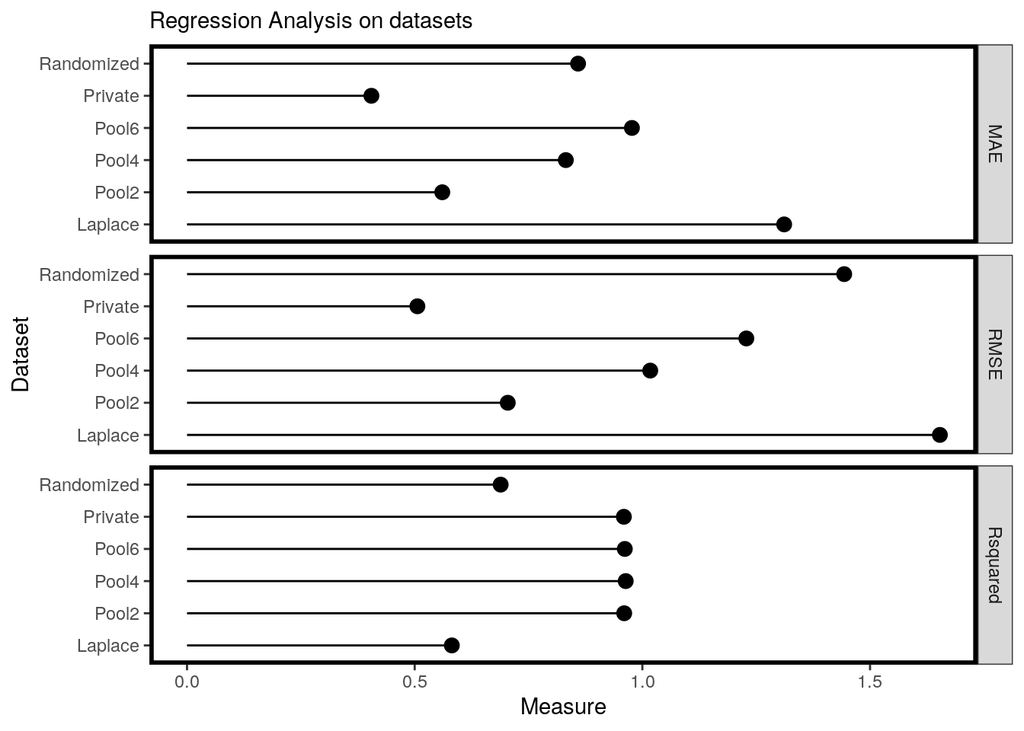

```r
all_rslt<-rbind(
lm_private$results[2:4],
lm_random$results[2:4],
lm_laplace$results[2:4],
lm_pool2$results[2:4],
lm_pool4$results[2:4],
lm_pool6$results[2:4]
)
all_rslt$Data<-c("Private","Randomized","Laplace","Pool2","Pool4","Pool6")

all_rslt_long<-gather(all_rslt,"Metric","Value",1:3)

# plot all the results separated by the metric used fo rthe analysis
df = all_rslt_long
ggplot(df, aes(Data, Value)) +
  #geom_bar(stat = "identity",size=0.5, position = position_dodge(0.8),width = 0.7,aes(fill=Data)) +
  geom_point(size=3) +
  geom_segment(aes(x=Data,
                   xend=Data,
                   y=0,
                   yend=Value)) +
  ylab("Measure") + xlab("Dataset") + coord_flip() +
  facet_grid(Metric ~., scales = "free")  +
  theme(axis.text.x = element_text(vjust = +.65,angle = 45, size = 0.15)) +
  labs(subtitle="Regression Analysis on datasets")+
  scale_fill_hue(name = "") + ljtheme +
    theme(legend.position = "none",
        legend.background = element_rect(fill="lightgray",
                                  size=0.5, linetype="solid"))
```

```r
lm_private <- lm(y ~., data = simulated)
lm_random <- lm(y ~., data = diff_randomized)
lm_laplace <- lm(y ~., data = as.data.frame(diff_laplace) )
lm_pool2 <- lm(y ~., data = pool2)
lm_pool4 <- lm(y ~., data = pool4)
lm_pool6 <- lm(y ~., data = pool6)

vals=tab_model(lm_private,lm_random,lm_laplace,lm_pool2,lm_pool4,lm_pool6,show.p = F,auto.label = FALSE)
vals
```

|  | y |  | y |  | y |  | y |  | y |  | y |  |
| --- | --- | --- | --- | --- | --- | --- | --- | --- | --- | --- | --- | --- |
| Predictors | Estimates | CI | Estimates | CI | Estimates | CI | Estimates | CI | Estimates | CI | Estimates | CI |
| (Intercept) | 0.00 | -0.03 – 0.03 | -0.02 | -0.11 – 0.07 | 0.03 | -0.07 – 0.14 | 0.00 | -0.06 – 0.06 | 0.00 | -0.13 – 0.13 | 0.00 | -0.18 – 0.19 |
| X1 | -2.15 | -2.18 – -2.12 | -1.91 | -2.00 – -1.82 | -1.30 | -1.38 – -1.22 | -2.16 | -2.20 – -2.12 | -2.15 | -2.21 – -2.09 | -2.18 | -2.26 – -2.10 |
| X2 | -0.64 | -0.68 – -0.61 | -0.46 | -0.55 – -0.36 | -0.43 | -0.52 – -0.35 | -0.65 | -0.69 – -0.60 | -0.60 | -0.67 – -0.54 | -0.58 | -0.66 – -0.50 |
| X3 | -0.95 | -0.98 – -0.92 | -0.84 | -0.93 – -0.75 | -0.61 | -0.70 – -0.53 | -0.94 | -0.98 – -0.90 | -0.93 | -1.00 – -0.87 | -0.90 | -0.98 – -0.81 |
| Observations | 1000 |  | 1000 |  | 1000 |  | 500 |  | 250 |  | 166 |  |
| R<sup>2</sup> / R<sup>2</sup> adjusted | 0.960 / 0.959 |  | 0.685 / 0.684 |  | 0.579 / 0.578 |  | 0.962 / 0.961 |  | 0.962 / 0.961 |  | 0.962 / 0.961 |  |

### Pooled epsilon differential data

```r
divpool2  = pool(poolsize=2,randomized_keep)
divpool4  = pool(poolsize=4,randomized_keep)
divpool6  = pool(poolsize=6,randomized_keep)
divpool10  = pool(poolsize=10,randomized_keep)

lm_pool2 <- lm(y ~., data = divpool2)
lm_pool4 <- lm(y ~., data = divpool4)
lm_pool6 <- lm(y ~., data = divpool6)
lm_pool10 <- lm(y ~., data = divpool10)

tab_model(lm_pool2,lm_pool4,lm_pool6,lm_pool10)
```

|  | y |  |  | y |  |  | y |  |  | y |  |  |
| --- | --- | --- | --- | --- | --- | --- | --- | --- | --- | --- | --- | --- |
| Predictors | Estimates | CI | p | Estimates | CI | p | Estimates | CI | p | Estimates | CI | p |
| (Intercept) | -0.05 | -0.23 – 0.14 | 0.619 | -0.09 | -0.48 – 0.29 | 0.627 | -0.11 | -0.68 – 0.47 | 0.712 | -0.24 | -1.19 – 0.72 | 0.625 |
| X1 | -1.90 | -2.03 – -1.77 | **<0.001** | -1.96 | -2.15 – -1.77 | **<0.001** | -1.96 | -2.19 – -1.72 | **<0.001** | -2.17 | -2.51 – -1.83 | **<0.001** |
| X2 | -0.48 | -0.62 – -0.35 | **<0.001** | -0.38 | -0.58 – -0.19 | **<0.001** | -0.35 | -0.59 – -0.11 | **0.004** | -0.27 | -0.59 – 0.06 | 0.109 |
| X3 | -0.85 | -0.98 – -0.72 | **<0.001** | -0.82 | -1.02 – -0.62 | **<0.001** | -0.75 | -1.01 – -0.50 | **<0.001** | -0.78 | -1.12 – -0.44 | **<0.001** |
| Observations | 500 |  |  | 250 |  |  | 166 |  |  | 100 |  |  |
| R<sup>2</sup> / R<sup>2</sup> adjusted | 0.677 / 0.675 |  |  | 0.678 / 0.674 |  |  | 0.671 / 0.665 |  |  | 0.657 / 0.647 |  |  |

### Real data example

```r
library(datamicroarray)

# describe_data()
data('shipp', package = 'datamicroarray')
dim(shipp$x);table(shipp$y) # Always run directly in the console
```

```
## [1]   77 7129
```

```
##
## DLBCL    FL
##    58    19
```

```r
df<-scale(shipp$x[,1:100],center = T)
y<-shipp$y

library("d3heatmap")
#d3heatmap(scale(df[,sample(1:100,25)]), colors = "RdYlBu")
#heatmap(df[,sample(1:100,30)])

library(gplots)
cat("Private data")
```

```
## Private data
```

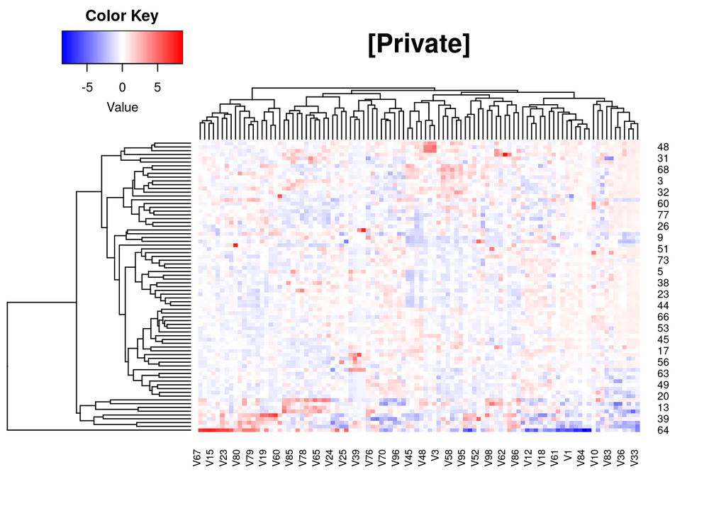

```r
heatmap.2(df, scale = "none", col = bluered(100),
          trace = "none", density.info = "none",main = "[Private]")
```

```r
cat("randomized")
```

```
## randomized
```

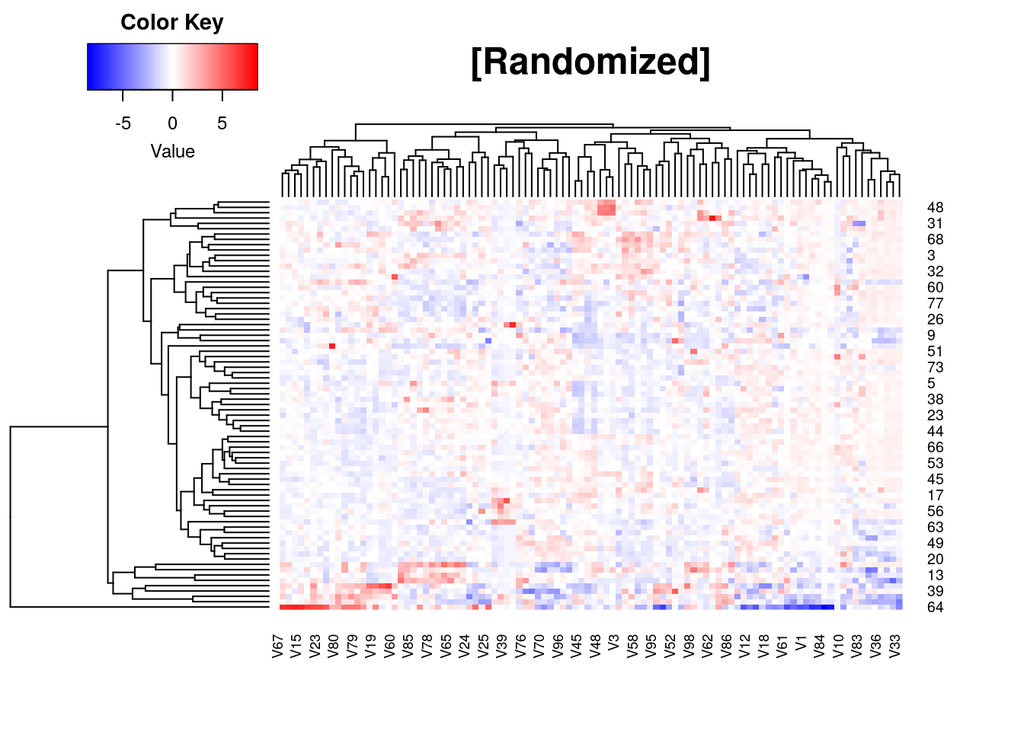

```r
# randomized private data
diff_index<-random_mechanism(y,alpha = 0.75,beta = 0.6)
diff_randomized<-as.matrix(df[which(y%in%c("DLBCL","FL")),])
heatmap.2(diff_randomized, scale = "none", col = bluered(100),
          trace = "none", density.info = "none",main = "[Randomized]")
```

```r
##3 laplace noise addition
cat("laplace data")
```

```
## laplace data
```

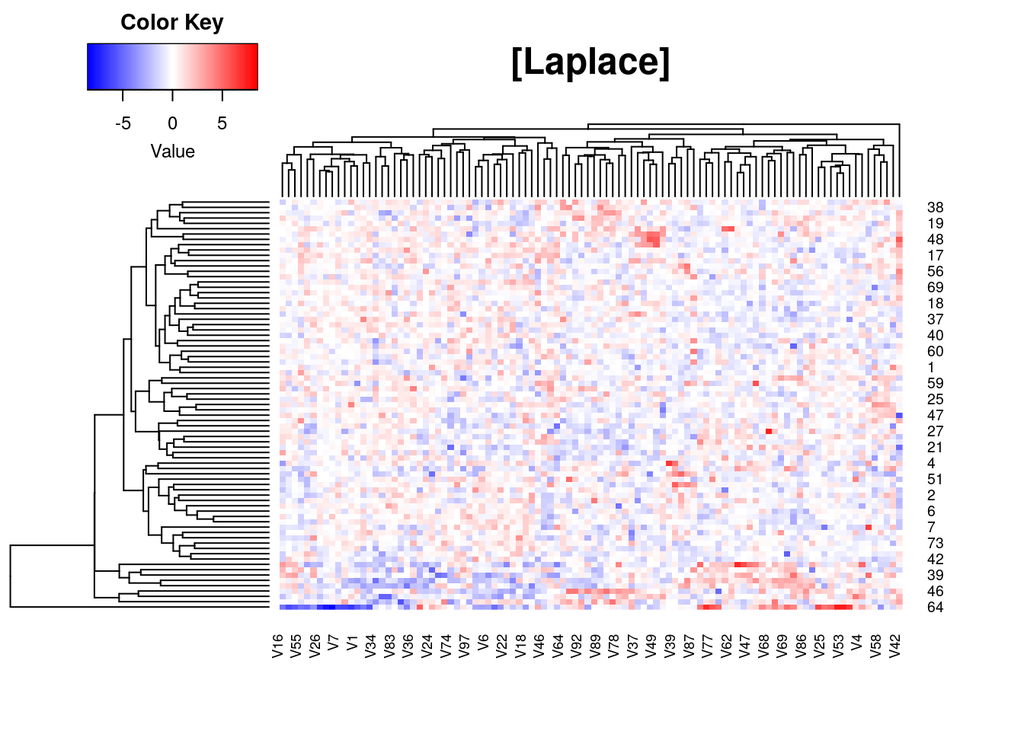

```r
diff_laplace<-apply(df,2,laplace_mech)
heatmap.2(diff_laplace, scale = "none", col = bluered(100),
          trace = "none", density.info = "none",main = "[Laplace]")
```

```r
# pool2

pool2  = pool(poolsize=2,df)
pool4  = pool(poolsize=4,df)
pool6  = pool(poolsize=6,df)
cat("Pool 2")
```

```
## Pool 2
```

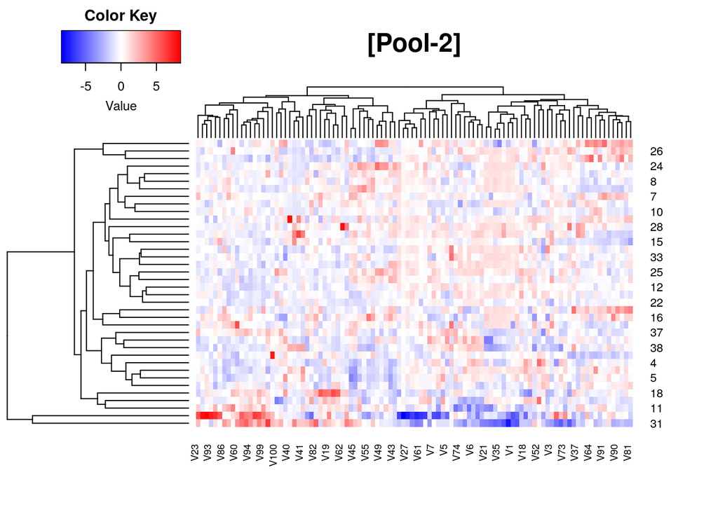

```r
heatmap.2(pool2, scale = "none", col = bluered(100),
          trace = "none", density.info = "none",main = "[Pool-2]")
```

```r
cat("Pool 4")
```

```
## Pool 4
```

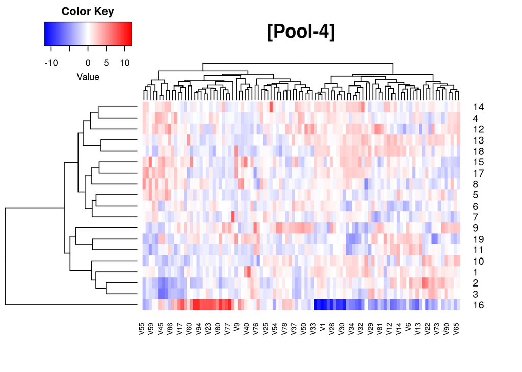

```r
heatmap.2(pool4, scale = "none", col = bluered(100),
          trace = "none", density.info = "none",main = "[Pool-4]")
```

```r
cat("Pool 6")
```

```
## Pool 6
```

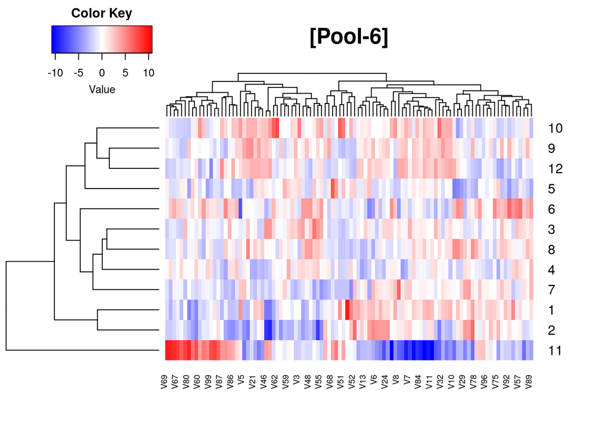

```r
heatmap.2(pool6, scale = "none", col = bluered(100),
          trace = "none", density.info = "none",main = "[Pool-6]")
```